# How might two small studies be better than one large study?

Jake Bowers

SBST and University of Illinois

June 15, 2016

Since an unbiased and consistent estimator may be very far from the truth when sample sizes are low one might ask whether it is better to direct resources to running two (or more) smaller studies rather than putting all of one’s eggs in one basket with one unbiased but possible far from the truth larger study.

```r
set.seed(1234568)
popN <- 1000000
popy <- rnorm(popN)
trueMeanY <- mean(popy)
trueMeanY
```

```
## [1] -0.000226811
```

```r
calcmeans <- function(n,popy){
    onemean <- mean(sample(popy,n,replace=FALSE))
    twomeansA <- mean(sample(popy,n/2,replace=FALSE))
    twomeansB <- mean(sample(popy,n/2,replace=FALSE))
    return(c(one=onemean,twoA=twomeansA,twoB=twomeansB))
}

## Test the function
calcmeans(10,popy)
```

```
##        one       twoA       twoB
## -0.2481268 -0.4153071  0.3268320
```

Across many re-samples, all the sample means should be unbiased. (We see this below. The mean of the means are approximately equal to the true mean – easily within sqrt(1/nsims) simulation error.) We also see that the sample mean is consistent — the bias decreases as the sample size increases. I think that we can formalize this question simply as, “When is an estimator based on two means using smaller samples better than an estimator based one mean with a larger sample?” I’m side-stepping a version of this question whereby we are updating scientific beliefs about a population quantity and instead am just focusing on properties of estimators because I think that this is pretty close to the actual scientific question (When can we learn more from two small studies than from one large study) and is a lot easier to explore. I’m also doing this by simulation. The analytics here (in the setup I use below) actually are not that hard.

```r
## Using all cores
library(parallel)
ncores <- detectCores()

# ns <- c(10,20,50,100,200,500,1000,2000,5000,10000,50000,100000,500000,900000,950000)
ns <- c(seq(8,120,by=4),seq(120,1000,by=20))
ns <- unique(ns[ ns %% 2 == 0 ])

nsims <- 100000

set.seed(1234567)
res <- mclapply(ns,function(n){
            message(n)
            replicate(nsims,calcmeans(n=n,popy))
},mc.cores=ncores)
save(res,file="multistudyquestion.rda")
```

```r
resArr <- simplify2array(res)
dimnames(resArr)[[3]]<-ns

twomeanEst <- apply(resArr[c("twoA","twoB"),,],c(2,3),mean)

## Bias
onemean <- abs( apply(resArr,c(1,3),mean) - trueMeanY )
twomeanBias <- abs( apply(twomeanEst, 2, mean) - trueMeanY )
biastab <- rbind(onemean,twomeanBias)

## Variance
onemeanSD <- apply(resArr,c(1,3),sd)
twomeanSD <-  apply( twomeanEst , 2, sd)
efftab <- rbind(onemeanSD,twomeanSD)

## MSE
## var + bias^2
onemeanMSE <- apply(resArr,c(1,3),function(x){ var(x) + (mean(x) - trueMeanY)^2 })
twomeanMSE <- apply(twomeanEst,2,function(x){ var(x) + (mean(x) - trueMeanY)^2 })
msetab <- rbind(onemeanMSE,twomeanMSE)
```

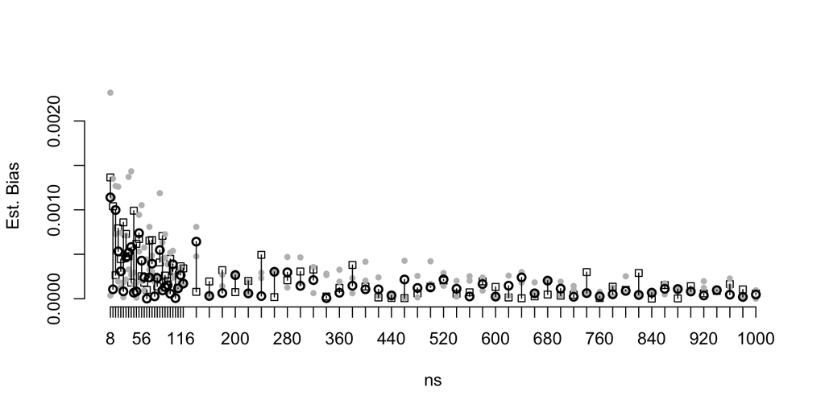

```r
matplot(y=t(biastab),x=ns,axes=FALSE,ylab="Est. Bias",type="p",
    lty=c(3,2,2,1),
    lwd=c(1,1,1,2),
    pch=c(22,20,20,1),
    col=c("black","grey","grey","black"))
segments(x0=ns,y0=t(biastab)[,4],x1=ns,y1=t(biastab)[,1])
axis(1,labels=ns,at=ns)
axis(2)
```

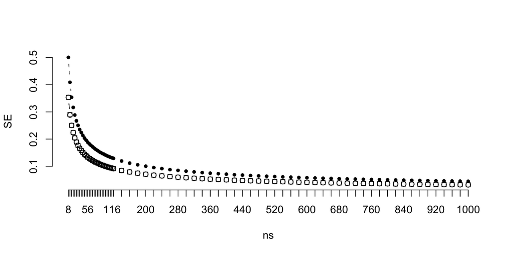

```r
matplot(y=t(efftab),x=ns,axes=FALSE,ylab="SE",type="b",
    lty=c(4,2,2,1),
    lwd=c(1,.5,.5,1),
    pch=c(1,20,20,22),col="black")
axis(1,labels=ns,at=ns)
axis(2)
```

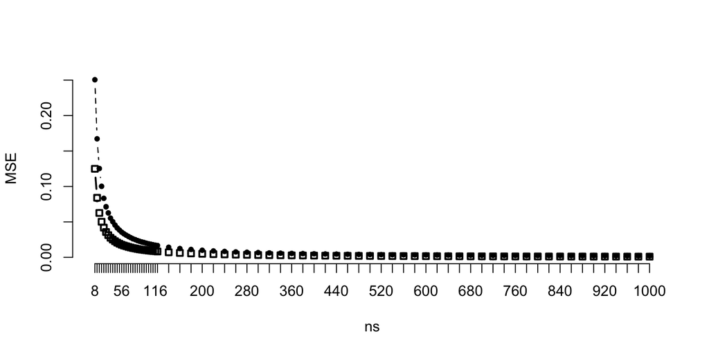

```r
matplot(y=t(msetab),x=ns,axes=FALSE,ylab="MSE",type="b",
    lty=c(4,2,2,1),
    lwd=c(1,1,1,2),
    pch=c(1,20,20,22),col="black")
axis(1,labels=ns,at=ns)
axis(2)
```